# Project 3 Data Science NanoDegree

**Principal Component Analysis**

```r
#subset out the feature set for pca analysis

log.wqr <- log(wqr[, 2:12])
partial.wqr <- wqr[, 2:12]
redwine.quality <- wqr[, 14]

# apply PCA - scale. = TRUE is highly
# advisable, but default is FALSE.
redwine.pca <- prcomp(partial.wqr,
                 center = TRUE,
                 scale. = TRUE)

summary(redwine.pca)
```

```
## Importance of components:
##                           PC1    PC2    PC3    PC4     PC5     PC6     PC7
## Standard deviation     1.7604 1.3878 1.2452 1.1015 0.97943 0.81216 0.76406
## Proportion of Variance 0.2817 0.1751 0.1410 0.1103 0.08721 0.05996 0.05307
## Cumulative Proportion  0.2817 0.4568 0.5978 0.7081 0.79528 0.85525 0.90832
##                            PC8     PC9    PC10    PC11
## Standard deviation     0.65035 0.58706 0.42583 0.24405
## Proportion of Variance 0.03845 0.03133 0.01648 0.00541
## Cumulative Proportion  0.94677 0.97810 0.99459 1.00000
```

```r
print(redwine.pca)
```

```
## Standard deviations:
##  [1] 1.7604353 1.3877715 1.2452082 1.1014684 0.9794346 0.8121627 0.7640623
##  [8] 0.6503512 0.5870623 0.4258323 0.2440457
##
## Rotation:
##                              PC1          PC2         PC3          PC4
## fixed.acidity         0.48931422 -0.110502738  0.12330157 -0.229617370
## volatile.acidity     -0.23858436  0.274930480  0.44996253  0.078959783
## citric.acid           0.46363166 -0.151791356 -0.23824707 -0.079418256
## residual.sugar        0.14610715  0.272080238 -0.10128338 -0.372792562
## chlorides             0.21224658  0.148051555  0.09261383  0.666194756
## free.sulfur.dioxide  -0.03615752  0.513566812 -0.42879287 -0.043537818
## total.sulfur.dioxide  0.02357485  0.569486959 -0.32241450 -0.034577115
## density               0.39535301  0.233575490  0.33887135 -0.174499758
## pH                   -0.43851962  0.006710793 -0.05769735 -0.003787746
## sulphates             0.24292133 -0.037553916 -0.27978615  0.550872362
## alcohol              -0.11323206 -0.386180959 -0.47167322 -0.122181088
##                              PC5         PC6         PC7         PC8
## fixed.acidity         0.08261366 -0.10147858  0.35022736 -0.17759545
## volatile.acidity     -0.21873452 -0.41144893  0.53373510 -0.07877531
## citric.acid           0.05857268 -0.06959338 -0.10549701 -0.37751558
## residual.sugar       -0.73214429 -0.04915555 -0.29066341  0.29984469
## chlorides            -0.24650090 -0.30433857 -0.37041337 -0.35700936
## free.sulfur.dioxide   0.15915198  0.01400021  0.11659611 -0.20478050
## total.sulfur.dioxide  0.22246456 -0.13630755  0.09366237  0.01903597
## density              -0.15707671  0.39115230  0.17048116 -0.23922267
## pH                   -0.26752977  0.52211645  0.02513762 -0.56139075
## sulphates            -0.22596222  0.38126343  0.44746911  0.37460432
## alcohol              -0.35068141 -0.36164504  0.32765090 -0.21762556
##                               PC9        PC10         PC11
## fixed.acidity         0.194020908  0.24952314  0.639691452
## volatile.acidity     -0.129110301 -0.36592473  0.002388597
## citric.acid          -0.381449669 -0.62167708 -0.070910304
## residual.sugar        0.007522949 -0.09287208  0.184029964
## chlorides             0.111338666  0.21767112  0.053065322
## free.sulfur.dioxide   0.635405218 -0.24848326 -0.051420865
## total.sulfur.dioxide -0.592115893  0.37075027  0.068701598
## density               0.020718675  0.23999012 -0.567331898
## pH                   -0.167745886  0.01096960  0.340710903
## sulphates            -0.058367062 -0.11232046  0.069555381
## alcohol               0.037603106  0.30301450 -0.314525906
```

Throughout this analysis, it always seemed that I might possibly be missing some hidden connections between the variables. Then I remembered that principal component analysis is one powerful way to reveal hidden structure within the data-set. It can help identify how variables work together, and maybe reduce the dimensionality of the data. Principal component 1 (PC1) contains only 28% of the total variance within the 11 possibly correlated ‘independent’ variables. And as for dimensionality reduction, PC1-PC9 contains > ~98% of the variance providing a dimensionality reduction of 2 using a cutoff of 95% variance captured.

Looking at the breakdown of first two principal components: PC1 is a principal component made up of the variables related to acidity and pH and PC2 is primarily related to sulfur dioxide. PC2 is interesting because this actually in keeping with the findings in the sulphate/sulfur dioxide exploration I performed above. Sulfur dioxide both free and total are major components of PC2 but sulphate contributes almost no variance to PC2. PC3 is the one that has some significant contribution from alcohol.

The results of the principal component analysis reveals that there’s not a super dominant component, this is also in keeping with the linear regression where it took a majority of the variables to get the best scores. I think I will use PCA much earlier in my exploratory data analysis in the future.

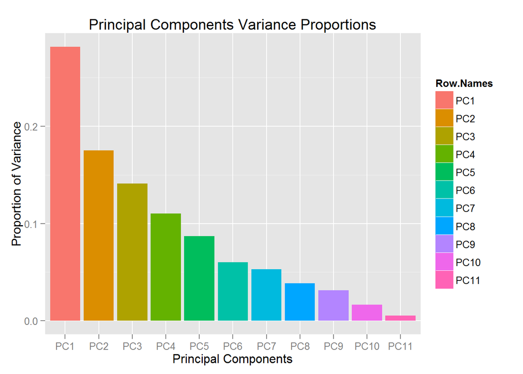

```r
#Preparing a dataframe to plot principal component Variances
pcaSum <- summary(redwine.pca)
varProp <- pcaSum$importance
tvarProp <- t(varProp)
tvarProp <- cbind(Row.Names = rownames(tvarProp), tvarProp)
tvarProp = as.data.frame(tvarProp)
names(tvarProp)[3]<-'Proportion.of.Variance'
names(tvarProp)[4]<-'Cumulative.Variance'
tvarProp$Cumulative.Variance =
  as.numeric(as.character(tvarProp$Cumulative.Variance))
tvarProp$Proportion.of.Variance =
  as.numeric(as.character(tvarProp$Proportion.of.Variance))

tvarProp <- transform(tvarProp, Row.Names = factor(Row.Names,
    levels = c("PC1", "PC2", "PC3", "PC4", "PC5", "PC6", "PC7",
               "PC8","PC9","PC10","PC11"), ordered = TRUE))

#graphical representation of variance proportions of the principal components
ggplot(aes(x = Row.Names, y = Proportion.of.Variance, fill = Row.Names),
       data = tvarProp) +
  geom_bar(stat='identity') +
  labs(x='Principal Components', y='Proportion of Variance') +
  ggtitle('Principal Components Variance Proportions')
```

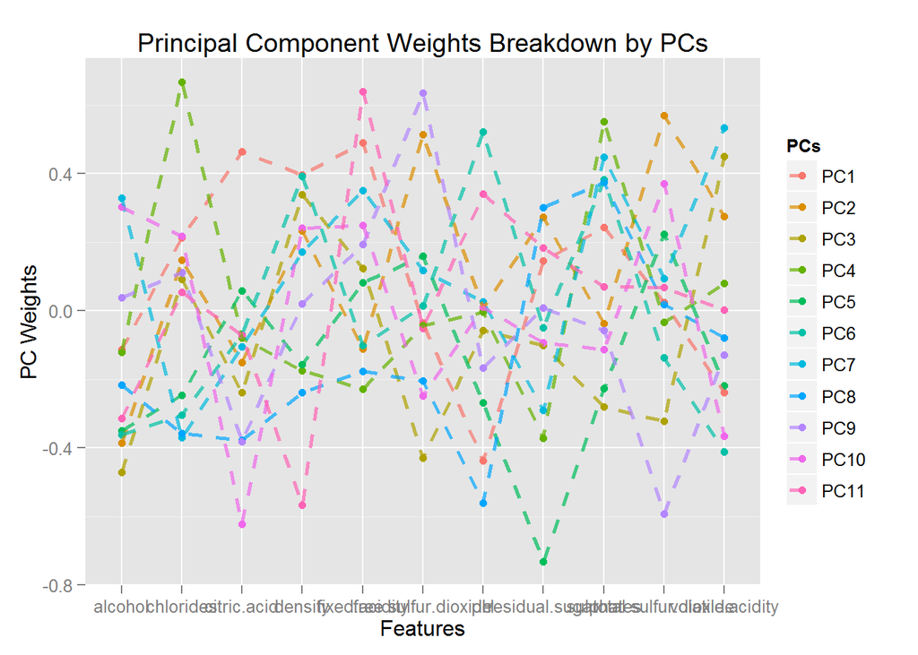

```r
#prep pca analysis results for plotting
pcaRotation <- redwine.pca$rotation
pcaRotation = as.data.frame(pcaRotation)
rotNames <- cbind(Row.Names = rownames(pcaRotation), pcaRotation)
tidyPCA <-  tidyr::gather(rotNames, 'PC','Weights', 2:12)
tidyPCA$PCs = tidyPCA$variable

#graphical representation of the principal Component weights
ggplot(aes(x = Row.Names, y = value, color = PCs, group = PCs),
             data = tidyPCA) +
  geom_point() + geom_line(size = 1, alpha = .7, linetype = 2) +
  labs(x='Features', y='PC Weights') +
  ggtitle('Principal Component Weights Breakdown by PCs')
```

```r
pcaSum <- summary(redwine.pca)
```

The graphical representation of the results of the principal component analysis can allow for a quick overview of the top contributors to individual principal components as well as the proportions of and cumulative variance. The dotted lines for the *PC Weights Breakdown* graph makes it easier to trace the line.

### 4: Final Plots and Summary

After the investigation of the data set and numerous dead ends, the two variables have seem to have the strongest affect on red wine quality are Volatile Acidity and Alcohol.

#### Plot One

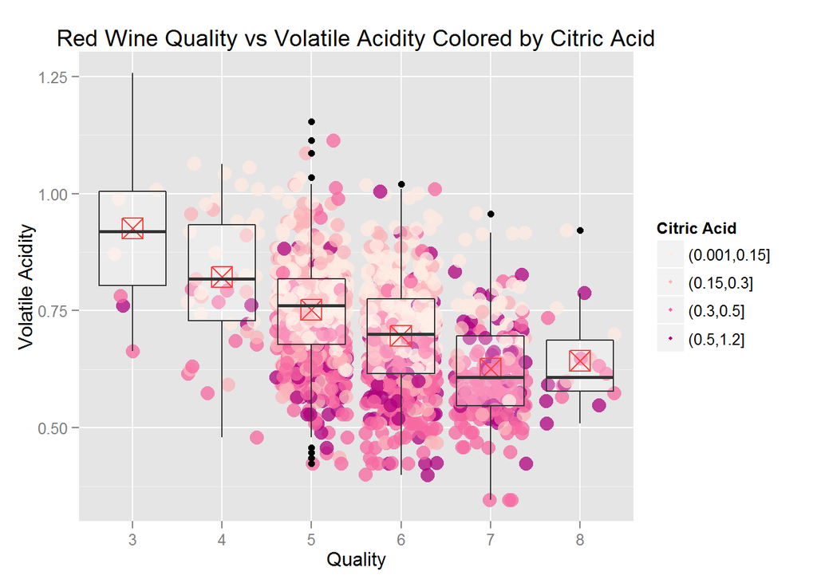

```r
ggplot(aes(y = sqrt(volatile.acidity), x = factor(quality) ), data = wqr) +
  geom_point(aes(color=cAcid.cut), position = 'jitter', size = 4, alpha = .75) +
  stat_summary(fun.y = mean, geom = 'point',size = 6, shape = 7,color = 'red') +
  geom_boxplot(alpha = 0.25)+
  scale_color_brewer(type = 'seq', palette = 'RdPu',
    guide = guide_legend(title = 'Citric Acid', reverse = F,
    override.aes = list(alpha = 1, size = 1)))+
  ggtitle('Red Wine Quality vs Volatile Acidity Colored by Citric Acid')+
  labs(x='Quality', y='Volatile Acidity')
```

Volatile Acidity seems to be one of the primary contributors to quality, the box plot aids to reveal the linear nature of this input variable to the dependent. An added observation/visualization is that citric acid is negative correlation of Citric Acid and Volatile Acidity.

#### Plot Two

*Principal Component Analysis*

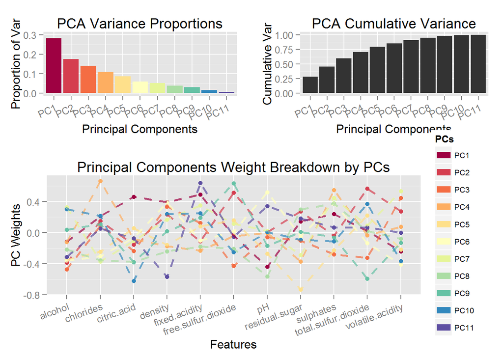

```r
p1 <- ggplot(aes(x = Row.Names, y = Proportion.of.Variance,
                 fill = Row.Names, group = Proportion.of.Variance),
             data = tvarProp) + geom_bar(stat='identity') +
  labs(x='Principal Components', y='Proportion of Var') +
  ggtitle('PCA Variance Proportions') +
  theme(axis.text.x = element_text(angle = 25, hjust = 1)) +
  scale_y_continuous(limits = c(0, 0.3)) +
  scale_fill_brewer(type = 'seq', palette = 'Spectral',
    guide = FALSE)

p2 <- ggplot(aes(x = Row.Names, y = Cumulative.Variance),
             data = tvarProp) + geom_bar(stat='identity') +
  labs(x='Principal Components', y = 'Cumulative Var') +
  ggtitle('PCA Cumulative Variance') +
  theme(axis.text.x = element_text(angle = 25, hjust = 1))


p3 <- ggplot(aes(x = Row.Names, y = value, color = PCs, group = PCs),
             data = tidyPCA) +
  geom_point() + geom_line(size = 1, alpha = .7, linetype = 2) +
  labs(x='Features', y='PC Weights') +
  ggtitle('Principal Components Weight Breakdown by PCs') +
  theme(axis.text.x = element_text(angle = 20, hjust = 1),
        legend.text = element_text(size = 8)) +
  scale_color_brewer(type = 'seq', palette = 'Spectral',
    guide = guide_legend(title = 'PCs', reverse = F,
    override.aes = list(alpha = 1, size = 3)))

grid.arrange(arrangeGrob(p1,p2, ncol=2), p3, ncol = 1, heights = c(1,1.5))
```

The graphical representation of the principal component analysis (PCA) helps to quickly visualize the distribution of the total variance in the data set. The bar graph showing the variance proportions for each PC and the color coordinated line graph showing the relative contributions of each variable to the respective PCs can give a quick way to find hidden relationships. The main relationships are acidity, sulfur dioxide, and alcohol corresponding to PC1, PC2 and PC3. It takes nine principal components to capture more than 95% of the total variance.

#### Plot Three

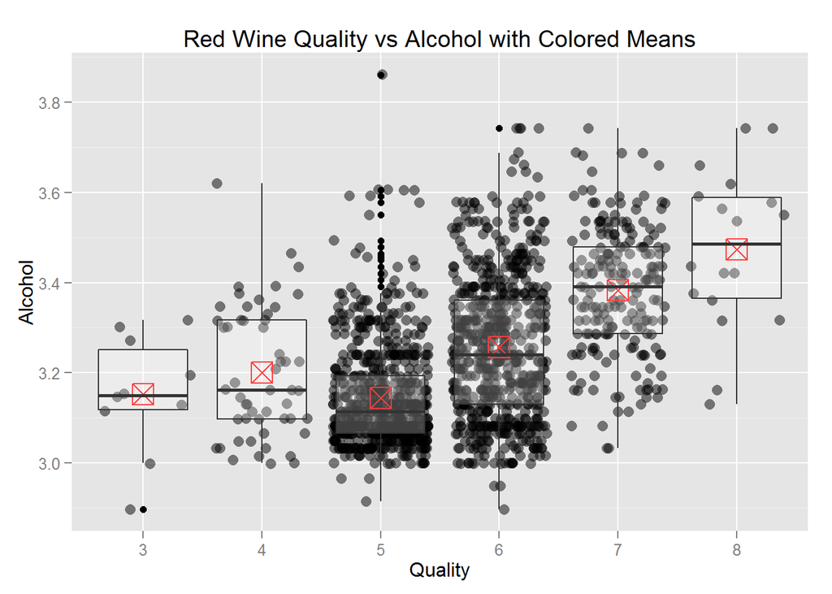

```r
ggplot(aes(y = sqrt(alcohol), x = factor(quality) ), data = wqr)+
  geom_point(position = 'jitter', size = 3, alpha = .5)+
  stat_summary(fun.y = mean, geom = 'point',size = 6, shape = 7,color = 'red') +
  geom_boxplot(alpha = 0.25)+
  scale_color_brewer(type = 'seq', palette = 'Dark2',
    guide = guide_legend(title = 'Free Sulfur Dioxide', reverse = F,
    override.aes = list(alpha = 1, size = 3)))+
  ggtitle('Red Wine Quality vs Alcohol with Colored Means')+
  labs(x='Quality', y='Alcohol')
```

The final low hanging insight is that alcohol is linearly correlated with quality and should be a significant contributor if one was to build a predictive model around the given variables and red wine quality. It seems that at least for red wine, higher alcohol content means better quality score!

#### Bonus Plot?

A tip from a friend lead me to the following investigation. Is there any bias in the observation number and the quality of the wine? Perhaps the experts were tired and observations with larger X could indicate scoring later in the process.

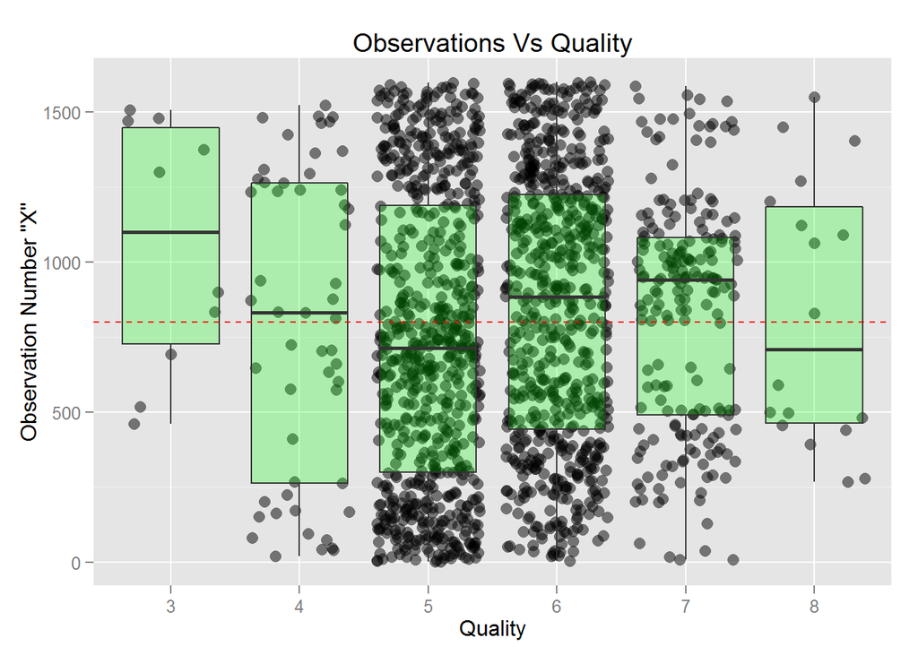

```r
ggplot(aes(y = X, x = factor(quality)), data = wqr) +
  geom_point(size = 3, alpha = 0.5, position = 'jitter') +
  geom_boxplot(alpha=0.25, fill = 'green')+
  geom_hline(yintercept = 800, linetype = 2, color = 'red') +
  ggtitle('Observations Vs Quality') +
  labs(y='Observation Number "X"', x='Quality')
```

Looking at the plot, it seems that aside from the exception of 3 quality wines, all other scoring seemed reasonably evenly distributed in terms of observations. The median tended towards the 800 mark as expected in a 1599 observation data set. One can reasonably assured that at least there was no bias introduced through the ordering of the observations if the original order was preserved.

### 5: Reflections

Exploring the Red Wine data-set has been somewhat frustrating. After coming from the lesson and the Diamonds and Facebook data-set where intuition paid off at least two times out of three, the red wine’s data refused to give up anything that was not somewhat obvious. Working with a qualitative/unbalanced sampling of the output/dependent variable was somewhat challenging as well. I keep thinking that discarding the bottom 2 and the top levels of the quality factor would vastly improve correlations at the risk of making the modeling trivial and losing all meaning to the data. The variables that affect Red Wine Quality most are *‘alcohol’*, *‘volatile.acidity’* and *‘sulphates’*. *‘citric.acid’* though correlated reasonably high with quality has high correlation with *‘volatile.acidity’* and loses much of its impact on the linear modeling due to the relationship. For the future, perhaps a non-linear model could be implemented and tested. Certain variables that I had hoped would show better correlation through informed factoring did not perform as expected (*‘free.sulfur.dioxide’*). Instead *‘total.sulfur.dioxide’* gave better correlation after factoring. The exploration of the red wine data-set has surprisingly taken more time than I expected. In the future I also think I will use Principal Component Analysis earlier in the exploration to quickly see if there are hidden or even more obvious relationships between variables. R is truly a powerful data analysis tool.